# Prosper Loan Borrower Features

## Investigation Overview

In this investigation, I wanted to look at the personal characteristics of Prosper loan borrowers that could be used to predict the types of borrowers that take out loans with Prosper in addition to profiling risk factors. The main focus were on borrower features such as rate, APR, credit, salary, occupation, state of residence, listing category, among others.

## Dataset Overview

The Prosper dataset consisted of 82 attributes with 113066 unique listings. I've decided to focus on about 23 user type features while removing other attributes that were mainly focused financial aspects of the loan itself.

### What is the structure of your dataset?

> The Prosper dataset consists of 82 attributes with 113066 unique listings. I've decided to focus on ~23 important features which include loan member characteristics and what might be driving factors of probability of loan payment. These variables differ from numeric to categorical. You can explore all variable definitions [here](https://docs.google.com/spreadsheets/d/1VtTHJgXz_oY8RRVGPKwFeYtN1BR23ZZMLJMqj_DaccQ/edit#gid=0).

### What is/are the main feature(s) of interest in your dataset?

> The main features of this dataset will be user, or who will be referred to in this analysis as "borrower", defined characteristics such as, state of residence, monthly income, credit rating, employment status, delinquent payments, borrower rate, occupation, loan status, among others to learn more about the Prosper borrower. This will help with determining not only the profile and risk of the borrower but, also potentially their ability and willingness to pay off the loan.

### What features in the dataset do you think will help support your investigation into your feature(s) of interest?

> I think the monthly income, debt to income ratio, monthly loan payments, employment status, occupation, credit grade ranges, and borrower state along with borrower rate and APR will be a great determiner in learning if our users will be able to payoff their loans.

## Univariate Exploration

### Let's look at Borrower Occupation to see any patterns or determine if there is more interest for loans in particular fields. This can help with Prosper Loan marketing teams and their efforts in marketing strategies.

### We see the top occupation is Other which doesn't supply much information however, the Professional is next, which can mean many things like management positions, or even a professional althlete, while Computer Programmer is third with Executive, and Teacher behind. Overall, we have education, technology, professionals and other, with some ambiguity, in the top 5.

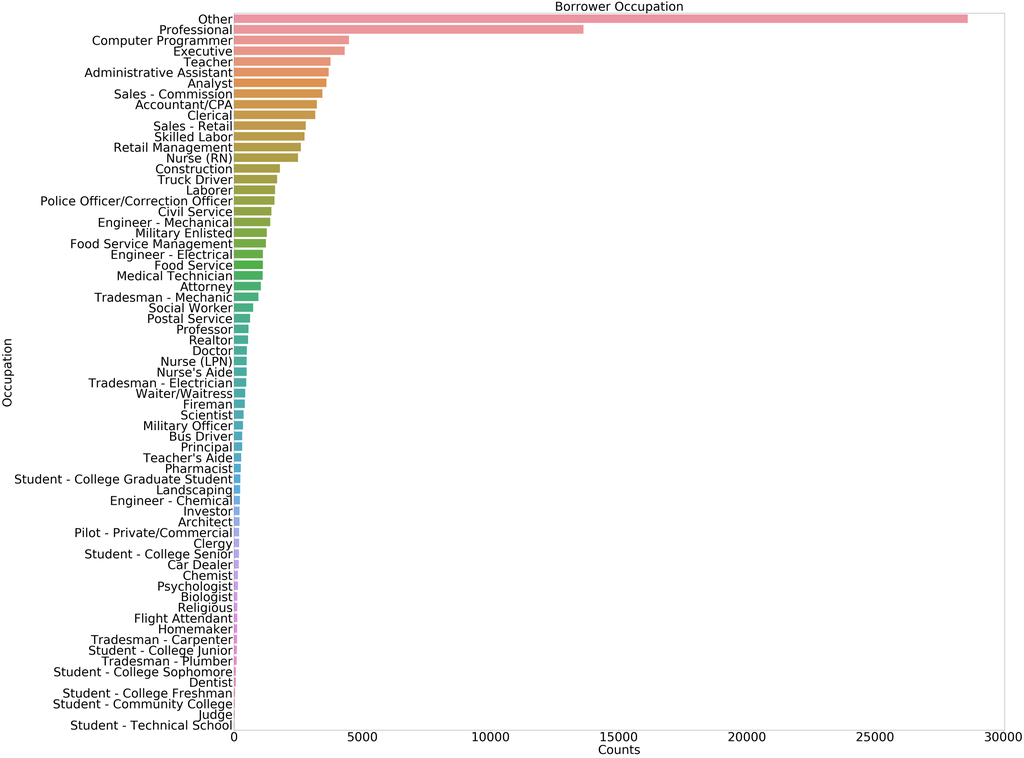

```python
# countplot, with order, as in above cell, to sort our occupations by frequency
plt.figure(figsize=[68, 65])

ax = sb.countplot(y="Occupation", data=prosper_clean, order =occupation_count)

plt.title('Borrower Occupation', fontsize=60)
plt.tick_params(labelsize=60)
plt.xlabel('Counts', fontsize=60)
plt.ylabel('Occupation', fontsize=60);
plt.show()
```

### Let's now look at our Borrower Rate, which refers to an interest rate additional cost of borrowing the principal loan amount

### Below we can see this is not exactly a normal distribution but, can be interpreted more as random skewness with different peaks with slight right skewness with peak at 0.15, a mean of 0.19, and then a peak again after 0.20 but, a drop around the 4000 frequency range with a random spike at ~0.32.

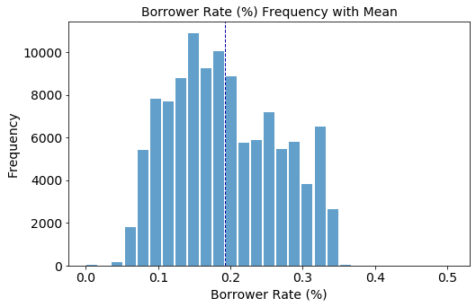

```python
# calcluate bins, and use the hist function with styling and a mean line
bins = np.arange(0, prosper_clean['BorrowerRate'].max()+0.0175,0.0175)

x = prosper_clean['BorrowerRate']

plt.figure(figsize=[8,5])
plt.hist(x, bins=bins, alpha=0.7, rwidth=0.85)

# here is our mean line using axvline()
plt.axvline(x.mean(), color='#0504aa', linestyle='dashed', linewidth=1)  # cite 3

plt.title('Borrower Rate (%) Frequency with Mean', fontsize=14)
plt.tick_params(labelsize=14)
plt.xlabel('Borrower Rate (%)', fontsize=14)
plt.ylabel('Frequency', fontsize=14);
```

### Next, we can see Borrower APR which is a range or measure on the loan cost that adds the Borrower Rate plus other costs such as fees, or discounts.

### Below we can see a similar pattern of random skewnness and a peak at ~0.18% and ~0.21%, while our mean of ~0.22% then seems to drop to about a 2700 frequency range but, thene rise slightly again just before 0.30% with a random peak again at ~0.36%.

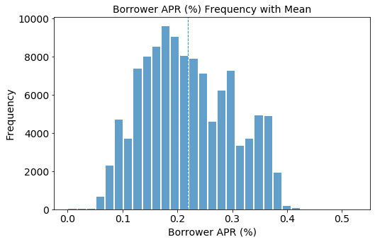

```python
# calculate the bins, with hist function, styling and mean line
bins = np.arange(0, prosper_clean['BorrowerAPR'].max()+0.017,0.017)

x = prosper_clean['BorrowerAPR']

plt.figure(figsize=[8,5])
plt.hist(x, bins=bins, alpha=0.7, rwidth=0.85)

# here is our mean line using axvline()
plt.axvline(x.mean(), color='#3498db', linestyle='dashed', linewidth=1)

plt.title('Borrower APR (%) Frequency with Mean', fontsize=14)
plt.tick_params(labelsize=14)
plt.xlabel('Borrower APR (%)', fontsize=14)
plt.ylabel('Frequency', fontsize=14);
```

### Viewing Estimated Return we see there is a spike at 0.01% tand somewhat of a right skewed distribution with a peak at about ~0.9% which shows estimated rate of returns with Prosper Loans are mostly within this range of 0.05% and 0.15%, while further investigation is required on the spike.

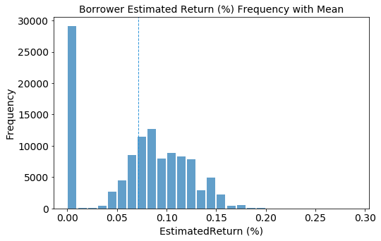

```python
# calculate the bins, get hist function, with styling and mean line
bins = np.arange(0, prosper_clean['EstimatedReturn'].max()+0.01,0.01)

x = prosper_clean['EstimatedReturn']

plt.figure(figsize=[8,5])
plt.hist(x, bins=bins, alpha=0.7, rwidth=0.85)

# here is our mean line using axvline()
plt.axvline(x.mean(), color='#3498db', linestyle='dashed', linewidth=1)

plt.title('Borrower Estimated Return (%) Frequency with Mean', fontsize=14)
plt.tick_params(labelsize=14)
plt.xlabel('EstimatedReturn (%)', fontsize=14)
plt.ylabel('Frequency', fontsize=14);
```

### Let's get a sense of the types of Listing Categories of our Borrowers with a simple histogram, then we'll order these categories using value_counts() and sort_values() descending to be stored to an order variable which we'll use in our catplot

### Our top 5 Listing Categories are Debt Consolidation, Not Available, Other, Home Improvement, Business which helps us further understand our Borrowers although the top 2 and 3 are ambiguous.

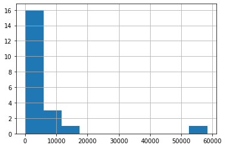

```python
# histogram of listing categories frequencies
prosper_clean['ListingCategory'].value_counts().hist()
```

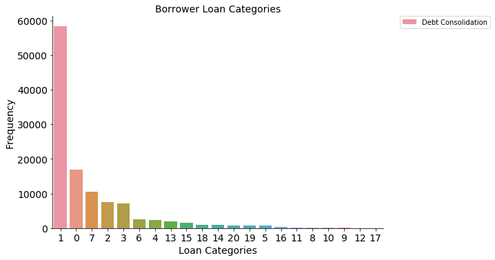

```python
# use catplot for listing categories frequencies with order descending
sb.catplot(x="ListingCategory", kind="count", data=prosper_clean,
           order =descending_order_listings, legend=True);

fig = plt.gcf() # cite 7
fig.set_size_inches(8,5)

cat_legend = ['Debt Consolidation', 'Not Available', 'Other', 'Home Improvement',
 'Business', 'Auto', 'Personal Loan', 'Household Expenses', 'Medical/Dental',
 'Taxes', 'Large Purchases', 'Wedding Loans', 'Vacation', 'Student Use',
 'Motorcycle', 'Engagement Ring', 'Baby&Adoption',  'Cosmetic Procedure',
 'Boat', 'Green Loans', 'RV']

plt.legend(cat_legend, bbox_to_anchor=(1.05, 1), loc=2, borderaxespad=0.)
plt.title('Borrower Loan Categories', fontsize=14)
plt.tick_params(labelsize=14)
plt.xlabel('Loan Categories', fontsize=14)
plt.ylabel('Frequency', fontsize=14)
plt.show()
```

### Let's look at Amount Delinquent with kernel density estimation plot to view density and frequencies which we can see results in an uneven distribution

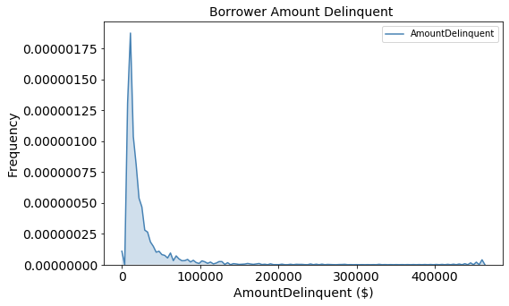

```python
# kdeplot with parameters: shade, color, bw
plt.figure(figsize=[8,5])
sb.kdeplot(prosper_clean['AmountDelinquent'], shade=True, color='steelblue', bw=5);

plt.tick_params(labelsize=14)

plt.title('Borrower Amount Delinquent ', fontsize=14)
plt.xlabel('AmountDelinquent ($)', fontsize=14)
plt.ylabel('Frequency', fontsize=14)
```

### The skewed bar chart above means we can go for a log scale instead for a normal distribution however, we still see skewness but, a general increase in frequency and then a peak at 100,000 as we get to our max() of 463,881 with log10 is 13.04

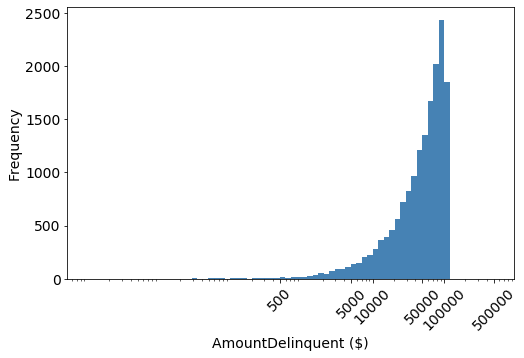

```python
# using np.logspace to get our bins with max value, use hist() to plot as a log scale
plt.figure(figsize=[8,5])

bins = np.logspace(0, np.log10(500000), 75)

plt.hist(x, bins=bins, color='steelblue')
plt.xscale('log')

plt.tick_params(labelsize=14)
plt.xlabel('AmountDelinquent ($)', fontsize=14)
plt.ylabel('Frequency', fontsize=14);
plt.xticks([500, 5000, 10000, 50000, 100000, 500000],
           [500, 5000, 10000, 50000, 100000, 500000], rotation=45);
```

### Let's look at our Credit Grade frequency across the dataset with a countplot, here we can see most credit grades are grade "C", with grade "D", and "B" as second and third.

### from our legend we know grade C is 630 to 679 which is on the higher risk side, while AA is a leading credit grade with little risk at number 4 in this order

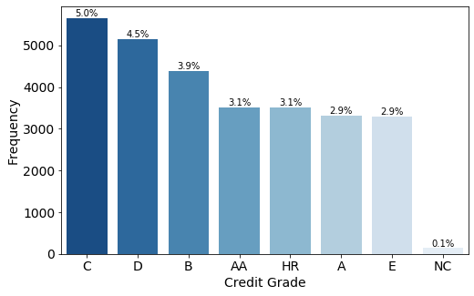

```python
# use countplot with order descending, and a reversed color palette
# iterate over ax.patches in order to get the percentages on top of our countplot bars
plt.figure(figsize=[8,5])

ax = sb.countplot(x="CreditGrade", data=prosper_clean, order=descending_order_grade, palette="Blues_r")

for p in ax.patches:  # cite 2
    x=p.get_bbox().get_points()[:,0]
    y=p.get_bbox().get_points()[1,1]
    ax.annotate('{:.1f}%'.format(100.*y/total_credit_shape), (x.mean(), y), ha='center', va='bottom')

letter_labels = ['C: 630-679','D: 550-629','B: 680-719','AA: 760+ ',
                 'HR: First Time Borrower', 'A: 720+','E: 520-','NC: No Credit']

plt.tick_params(labelsize=14)
plt.xlabel('Credit Grade', fontsize=14)
plt.ylabel('Frequency', fontsize=14);
```

### Here we use a countplot to view Loan Status of all Borrowers which shows very positively that 49.7% of loans are in current status, which ideally is great for a loan company! With ~10% charged off and ~4% defaulted are not as good but, yet relatively low numbers and we see no Borrowers are > 120 days overdue on their loans which looks promising!

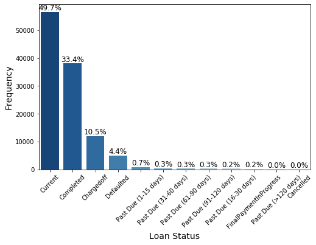

```python
# use countplot with styling with order descending and reversed color palette
# then iterate over ax.patches to put the percentage of each bar at the top of the bar
f, ax = plt.subplots(figsize=(8,5))

ax = sb.countplot(x="LoanStatus", data=prosper_clean,
                  order=descending_order, palette="Blues_r")

for p in ax.patches:
    x=p.get_bbox().get_points()[:,0]  # cite 2
    y=p.get_bbox().get_points()[1,1]
    ax.annotate('{:.1f}%'.format(100.*y/total_loan_status), (x.mean(), y),
            ha='center', va='bottom',  fontsize=12)

ax.set_ylabel('Frequency [%]')
plt.setp(ax.get_xticklabels(), rotation=45);
plt.xlabel('Loan Status', fontsize=14)
plt.ylabel('Frequency', fontsize=14);
```

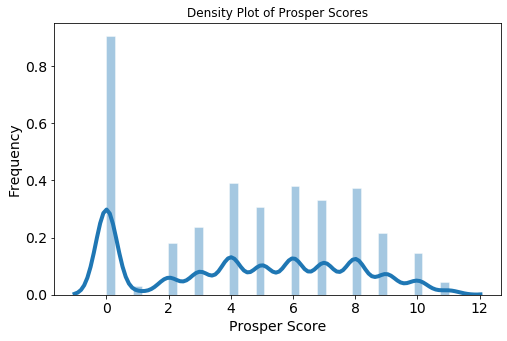

```python
# use distplot to get quick view of prosper score data ranges with kernel density estimate
plt.figure(figsize=[8, 5])
sb.distplot(prosper_clean.ProsperScore, hist=True, kde=True,  #  cite 6
             hist_kws={'edgecolor':'white'}, kde_kws={'linewidth': 4});

plt.tick_params(labelsize=14)
plt.title('Density Plot of Prosper Scores')
plt.xlabel('Prosper Score', fontsize=14)
plt.ylabel('Frequency', fontsize=14);
```

### The Debt to Income Ratio numbers look low while the mean shows Borrower's are averaging a 25.5% which as per industry standards anything, below a 36% is considered low. Using the displot with a rug plot we can see all values present in the dataset.

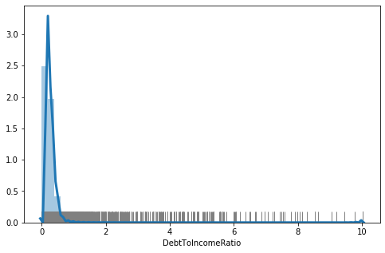

```python
# use distplot to get quick overview of debt to income ratio, adding rug plot
# with kernel density estimate set to true
plt.figure(figsize=[8,5])
sb.distplot(prosper_clean.DebtToIncomeRatio, kde=True, rug=True, hist = True,
             kde_kws={'linewidth': 3}, rug_kws={'color': 'grey'});
```

### Monthly Loan Payments appear to be mostly < 500 dollars but, can be upwards of 2000 while on average payments are at 272. Using distplot with histogram feature set to false we see the density line plot plus our rug plot

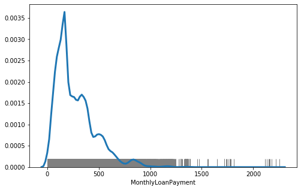

```python
# use displot to view monthly loan payment, histogram is false, add rug to show all values
# with kernel density estimate set to true
plt.figure(figsize=[8,5])
sb.distplot(prosper_clean.MonthlyLoanPayment, kde=True, rug=True, hist=False,
             kde_kws={'linewidth': 3}, rug_kws={'color': 'grey'});
```

### The Loan Origination Amount shows a wide range of loans between 1000 to 35000 with a mean of 8337

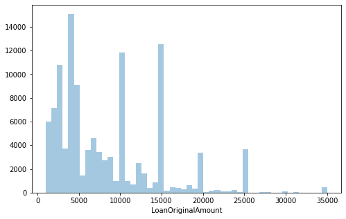

```python
# use distplot to get overview of loan original amounts, rug to show all values
# with kernel density estimate set to false
plt.figure(figsize=[8,5])
sb.distplot(prosper_clean.LoanOriginalAmount, kde=False, rug=False,
            kde_kws = {'shade': True, 'linewidth': 3});
```

### Discuss the distribution(s) of your variable(s) of interest. Were there any unusual points? Did you need to perform any transformations?

> The distplots gave a quick look at some key variables which help with determining whether the borrower will be able to payoff their loan. The Estimated Return, and Borrower's Rate, and APR showed more random distribution with some spikes while Monthly Loan Payment, and Debt to Income Ratio were skewed.

### Of the features you investigated, were there any unusual distributions? Did you perform any operations on the data to tidy, adjust, or change the form of the data? If so, why did you do this?

> There was variables that required operations to transform the data in order for the plot to work. For example, doing a sort_value() descending to order the count plots were necessary with for example with Borrower Occupation, Credit Grades, and Loan Status.

> The Amount Delinquent variable was unevenly distributed and could benefit from a log scale which required using np.logspace() for our bins, and setting bins to appropriate amount that would work given our values.

## Bivariate Exploration

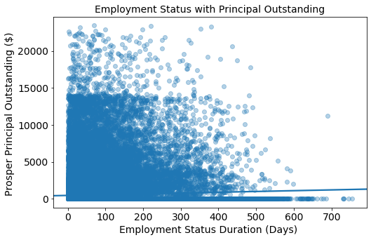

```python
# use regplot with styling and jitter because plots were too dense
plt.figure(figsize=[8,5])

sb.regplot(data = prosper_clean, x = 'EmploymentStatusDuration',
           y = 'ProsperPrincipalOutstanding', fit_reg=True,
           x_jitter = 0.2, y_jitter = 0.2, scatter_kws = {'alpha' : 1/3})

plt.tick_params(labelsize=14)
plt.title('Employment Status with Principal Outstanding', fontsize=14)
plt.xlabel('Employment Status Duration (Days) ', fontsize=14)
plt.ylabel('Prosper Principal Outstanding ($) ', fontsize=14);
```

### Taking a different approach now, let's view the number of homeowners we have by state that have taken out Prosper Loans using seaborn's countplot.

### We can see top results are in the state of CA on both counts with 14717 total, 39.97% as home owners, and 60.03% not home owners.

```python
# from our df home_owner_by_state index into our 'CA' column to get True/False values
# store them to variables and print out percentages
ca_ho_sum = home_owner_by_state['CA'][0] + home_owner_by_state['CA'][1]
ca_false = home_owner_by_state['CA'][0]/ca_ho_sum
ca_true =  home_owner_by_state['CA'][1]/ca_ho_sum

print('Total CA State Borrowers: ', ca_ho_sum, '\n',
      '- Total CA State Home Owners: ', round(ca_true*100,2), '%', '\n' ,
      '- Total CA State Not Home Owners: ', round(ca_false*100, 2), '%', '\n' )
```

```
Total CA State Borrowers:  14717
 - Total CA State Home Owners:  39.97 %
 - Total CA State Not Home Owners:  60.03 %
```

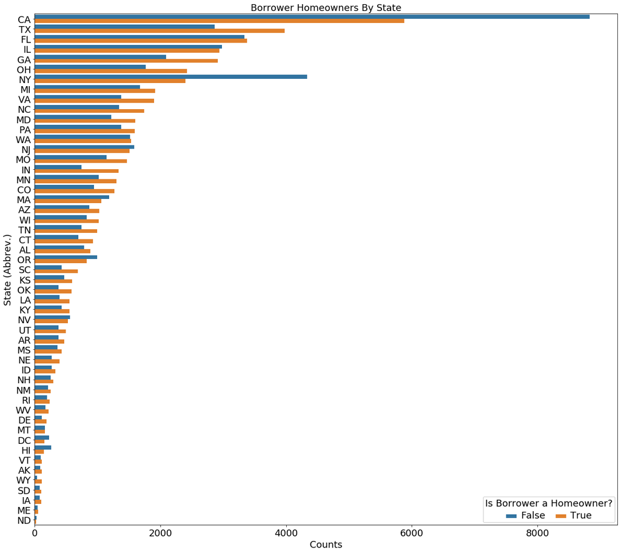

```python
# using countplot and order descending, with increased figuresize and styling
plt.figure(figsize=[20, 18])

ax = sb.countplot(data = prosper_clean, y='BorrowerState', hue='IsBorrowerHomeowner',
                  order =home_owner_by_state)


ax.tick_params(labelsize=18)
ax.legend(loc = 0, ncol = 3, framealpha = 3, title = 'Is Borrower a Homeowner?')

plt.title('Borrower Homeowners By State', fontsize=18)
plt.xlabel('Counts', fontsize=18)
plt.ylabel('State (Abbrev.)', fontsize=18);

plt.setp(ax.get_legend().get_texts(), fontsize='18')
plt.setp(ax.get_legend().get_title(), fontsize='18')

plt.show()
```

### Let's view Employment Status and how it is related to Monthly Loan Payments using seaborn's FacetGrid. Interestingly you can see payments are mostly from Borrower's who are employed while second ranked would be full time employed, then a cross between self-employed and not available.

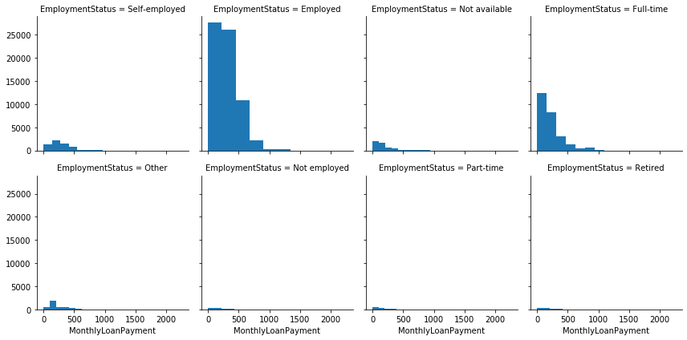

```python
# use facetgrid with col as a categorical variable and map each grid with a hist graph and four columns
g = sb.FacetGrid(data = prosper_clean, col = 'EmploymentStatus', col_wrap = 4, height = 3)
g.map(plt.hist, "MonthlyLoanPayment");
plt.show()
```

### Let's look now at our Borrower Stated Income and Available Bankcard Credit to see if there are any patterns, outliers and or dense areas to look further into:

### It seems our Borrowers have monthly incomes that are from 0 to less than 250,000, with upwards of 600,000 in bank credit while only 4 have less than 500,000 monthly income, 1 at about 650,000 and an outlier earning 1.75M of which have less than 100,000 in available bankcard credit. This number may not consider other banks the Borrower has relationships with but, overall this gives us a good snapshot of our Borrower's access to income/credit.

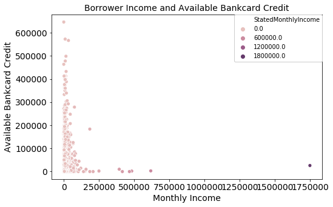

```python
# use scatterplot with cmap to get our coloring in a continuous fashion
# use jitter to bring random noise into the density
plt.figure(figsize=[8,5])

cmap = sb.cubehelix_palette(dark=.3, light=.8, as_cmap=True)

ax = sb.scatterplot(x='StatedMonthlyIncome', y='AvailableBankcardCredit',
                   hue="StatedMonthlyIncome", palette=cmap,
                   x_jitter = 0.2, y_jitter = 0.2, data = prosper_clean)


ax.tick_params(labelsize=14)
ax.legend(loc = 0, framealpha = 3, bbox_to_anchor=(1, 1), borderaxespad=0.)

plt.title('Borrower Income and Available Bankcard Credit', fontsize=14)
plt.xlabel('Monthly Income', fontsize=14)
plt.ylabel('Available Bankcard Credit', fontsize=14);
plt.show()
```

### Let's create a df to show only Loan Origination Date and Loan Original Amount then plot that df to see a time series and if there is any time of the year when Borrower's are requesting loans.

### In our time series we see a 2011, 2012, and 2013 with gains and loses but, ultimately a massive increase during 2014 with the largest origination of loans in the company's history since 2006. **Prosper Loan is aware there was a gap in data collection during 2009*

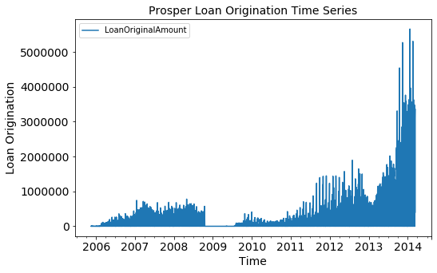

```python
# resample by day, summed and plotted
loan_origin_timeseries.resample('D').sum().plot(figsize=(8, 5), fontsize=14)

plt.title('Prosper Loan Origination Time Series', fontsize=14)
plt.xlabel('Time', fontsize=14)
plt.ylabel('Loan Origination', fontsize=14);
plt.show()
```

### Talk about some of the relationships you observed in this part of the investigation. How did the feature(s) of interest vary with other features in the dataset?

> From the start of this section, we looked at employment status duration in days with amount of principle outstanding, learning that density was prevalent in borrower's with less than 200 days employment having a principle outstanding of less than 5000 dollars. With regard to type of employment status most of our borrower's are employed, while second, third and fourth, were full-time, self-employed or info not available, respectively.

### Did you observe any interesting relationships between the other features (not the main feature(s) of interest)?

> A big insight which was not a feature was looking at a time series of loan origination where we can clearly see a drastic increase in originating loans during the year 2014. I would ask Prosper Loan teams to dig in deeper to see what they did and what was happening economically at the time to help increase overall business with the company.

## Multivariate Exploration

### Using a heatmap to plot correlation coefficients of our numeric variables that we reviewed in previous sections will give us insight into which were correlated or less correlated. From our statistics lesson we learned about strong, moderate and weak correlation relationships, eg: *[strong: 0.7 < 1.0, moderate: 0.3 < 0.7, weak: 0.0 < 0.3]*

### Our results show strong correlations for the following Borrower APR with Borrower Rate, Estimated Loss and Estimated Return with Estimated Loss

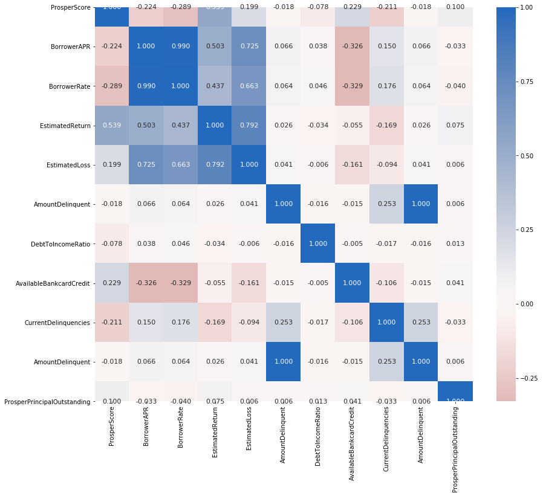

```python
# using heatmap get correlation, annotation, with cmap
plt.figure(figsize = [14, 12])
sb.heatmap(prosper_clean[numeric_vars].corr(), annot = True, fmt = '.3f',
           cmap = 'vlag_r', center=0, annot_kws={'size':11})

plt.show()
```

### Facet Grid let's us look at the multivariate relationships in our data, collecting a subset first of the variables we want to compare, we'll use a colorbar with a gradient to show continuous values in a scatter plot

### From our FacetGrid we can see Borrowers with income ranges between 25,000 to 100,000 are likely to be delinquent up to 100,000 with 200,000 second and outliers upwards of 400,000 of which 100,000 income range and 25,000 to 49,999 had this amount outlier.

```python
# quick percentage of these value counts
payments_subset['IncomeRange'].value_counts(normalize=True).mul(100).round(1).astype(str) + '%' # cite 8
```

```
$25,000-49,999    28.3%
$50,000-74,999    27.3%
$100,000+         15.2%
$75,000-99,999    14.8%
Not displayed      6.8%
$1-24,999          6.4%
Not employed       0.7%
$0                 0.5%
Name: IncomeRange, dtype: object
```

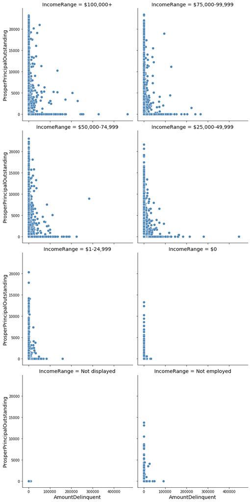

```python
# kws additional keyword args to pass to scatter plot
kws = dict(s=50, linewidth=.5, edgecolor="w")

# facetgrid will show our categorical incomes in a column grid
g = sb.FacetGrid(data=payments_subset, col='IncomeRange', height = 5, col_wrap = 2,
                 margin_titles= True)

# scatter will plot our two variables
g = (g.map(plt.scatter, "AmountDelinquent", "ProsperPrincipalOutstanding",
    **kws, color='steelblue'))

# iterate thorugh each axis
for ax in g.axes.flat: # cite 5
    # Make x and y-axis labels slightly larger
    ax.set_xlabel(ax.get_xlabel(), fontsize='x-large')
    ax.set_ylabel(ax.get_ylabel(), fontsize='x-large')

    # print('ax.get_title():', ax.get_title())
    # increase font size for facet grid labels
    if ax.get_title():
        # print('ax.set_title/get_title():', ax.set_title(ax.get_title()))
        ax.set_title(ax.get_title(), fontsize='x-large')


plt.show();
```

### Talk about some of the relationships you observed in this part of the investigation. Were there features that strengthened each other in terms of looking at your feature(s) of interest?

> The heatmap by correlation coefficient was helpful to see that really the only true features that had strong relationships were Borrower APR, Borrower Rate, Estimated Loss and Estimated Return. When reading more about interest rate, and APR you can see how that would impact a decision to take out a loan or wait until potentially a better rate was available.

> The other feature was borrower monthly income which ranged from 0 to over 100,000 and yet, most in the range of 25,000 to 100,000 had either less than 5000 principal outstanding or less than 100,000 delinquent but, fewer overall had delinquency. The outliers were two data points one delinquent over 400,000 in the 25,000 to 49,999 income range, and one delinquent about 300,000 and had about 10,000 principal outstanding.

### Were there any interesting or surprising interactions between features?

> The interesting or surprising interactions between features were learning that there were Borrowers marked as not employed for income range and yet one Borrower owned about $100,000.

#### Citations:

> 1. https://stackoverflow.com/questions/29803093/check-which-columns-in-dataframe-are-categorical?noredirect=1&lq=1
> 2. https://stackoverflow.com/questions/33179122/seaborn-countplot-with-frequencies
> 3. https://stackoverflow.com/questions/16180946/drawing-average-line-in-histogram-matplotlib
> 4. https://www.standardandpoors.com/en_US/web/guest/article/-/view/sourceId/504352
> 5. https://cduvallet.github.io/posts/2018/11/facetgrid-ylabel-access
> 6. https://towardsdatascience.com/histograms-and-density-plots-in-python-f6bda88f5ac0
> 7. https://stackoverflow.com/questions/51502927/adjusting-size-of-seaborn-plot
> 8. https://blog.softhints.com/pandas-count-percentage-value-column/